# Week 4 - Custom ggplot2 color schemes and themes

2/25/2020

# Color schemes

For a long time the default color schemes in ggplot2 weren’t very good and often didn’t work for printing in black and white or for people with various forms of color blindness. They have made some improvements, but one easy fix is to use the scale_xxx_viridis_c() and scale_xxx_viridis_d() functions that are now part of the ggplot2 package.

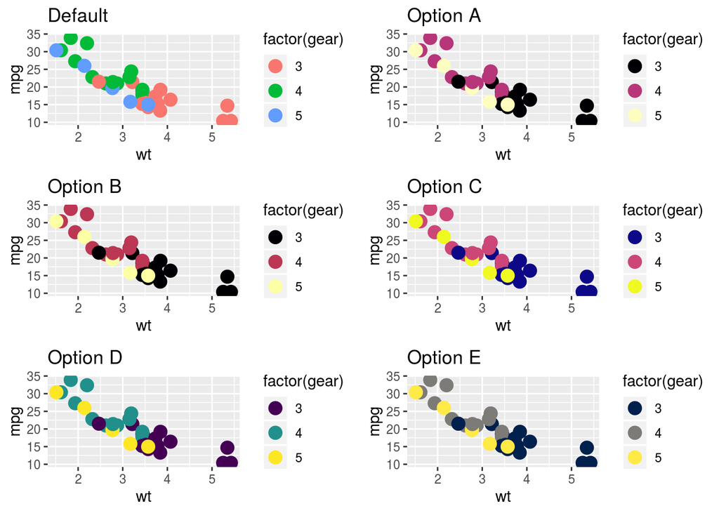

```r
library(ggplot2)
library(gridExtra)
g <- ggplot(mtcars, aes(x = wt, y = mpg, color = factor(gear))) +
  geom_point(size = 4)

g1 <- g + scale_color_viridis_d(option = "A") + ggtitle("Option A")
g2 <- g + scale_color_viridis_d(option = "B") + ggtitle("Option B")
g3 <- g + scale_color_viridis_d(option = "C") + ggtitle("Option C")
g4 <- g + scale_color_viridis_d(option = "D") + ggtitle("Option D")
g5 <- g + scale_color_viridis_d(option = "E") + ggtitle("Option E")
grid.arrange(g + labs(title = "Default"), g1, g2, g3, g4, g5, ncol = 2, nrow = 3)
```

These can be used for other types of plots as well

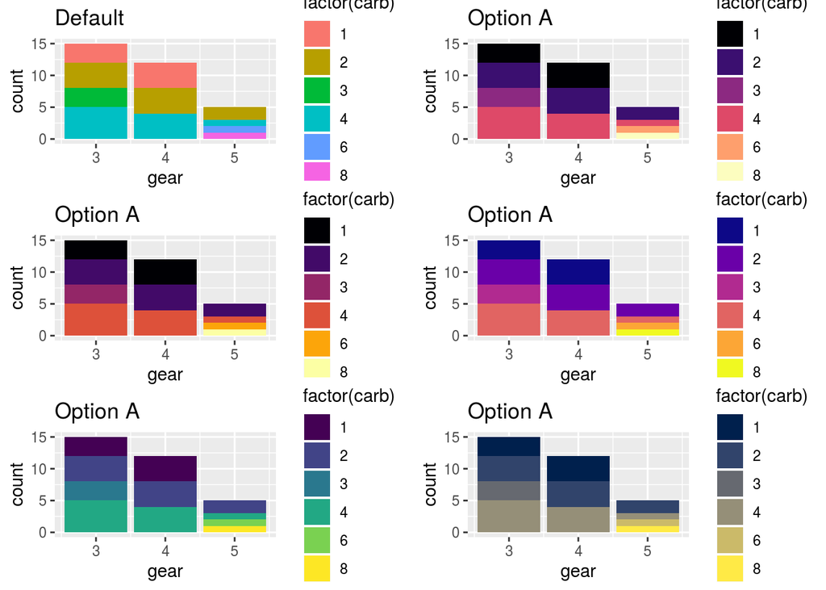

```r
g <- ggplot(mtcars, aes(x = gear, fill = factor(carb))) +
  geom_bar()

g1 <- g + scale_fill_viridis_d(option = "A") + ggtitle("Option A")
g2 <- g + scale_fill_viridis_d(option = "B") + ggtitle("Option A")
g3 <- g + scale_fill_viridis_d(option = "C") + ggtitle("Option A")
g4 <- g + scale_fill_viridis_d(option = "D") + ggtitle("Option A")
g5 <- g + scale_fill_viridis_d(option = "E") + ggtitle("Option A")
grid.arrange(g + labs(title = "Default"), g1, g2, g3, g4, g5, ncol = 2, nrow = 3)
```

However, there are also lots of other packages people have created to allow different color schemes.

# The gameofthrones Package

Let’s try our bar graphs again but this time with color schemes to match different houses in Game of Thrones. First lets look at what palettes are available.

```r
library(gameofthrones)

names(got_palettes)
```

```
##  [1] "targaryen"       "targaryen2"      "stark"           "stark2"
##  [5] "lannister"       "martell"         "tully"           "greyjoy"
##  [9] "baratheon"       "baratheon2"      "tyrell"          "white_walkers"
## [13] "jon_snow"        "margaery"        "daenerys"        "game_of_thrones"
## [17] "wildfire"        "arya"
```

Notice that there are usually five or six colors for each, so these may not work if you need a lot of colors. Let’s try a few of them below though.

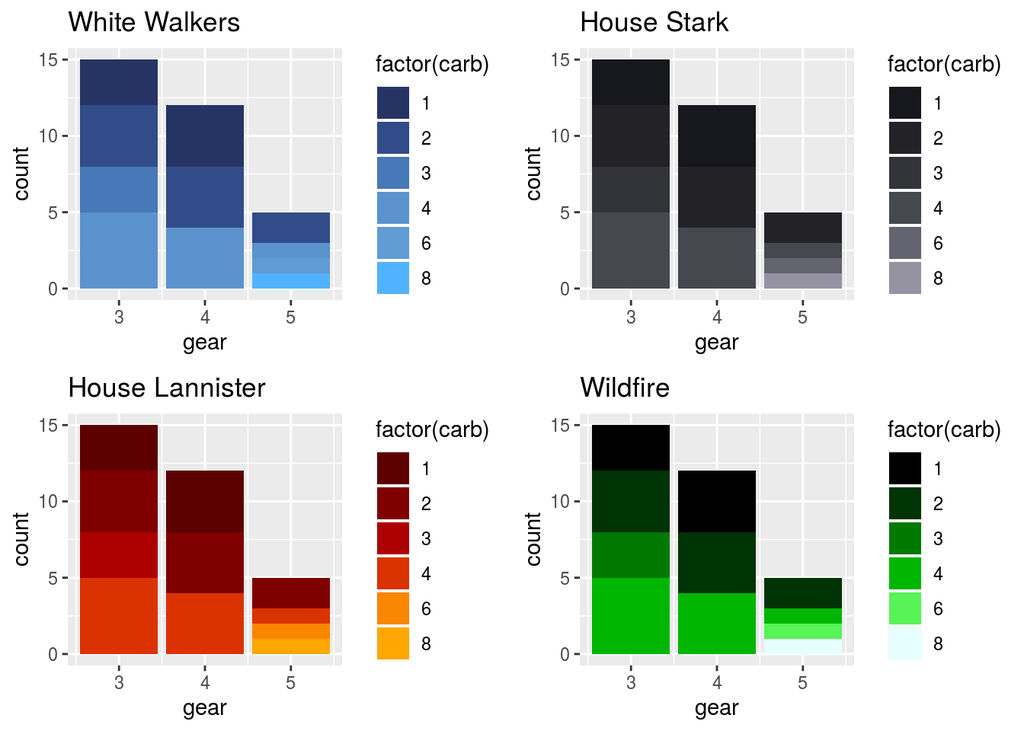

```r
g <- ggplot(mtcars, aes(x = gear, fill = factor(carb))) +
  geom_bar()

g1 <- g + scale_fill_got(option = "white_walkers", discrete = TRUE) +
  ggtitle("White Walkers")
g2 <- g + scale_fill_got(option = "stark", discrete = TRUE) +
  ggtitle("House Stark")
g3 <- g + scale_fill_got(option = "lannister", discrete = TRUE) +
  ggtitle("House Lannister")
g4 <- g + scale_fill_got(option = "wildfire", discrete = TRUE) +
  ggtitle("Wildfire")
grid.arrange(g1, g2, g3, g4, ncol = 2, nrow = 2)
```

For more examples, see here: https://github.com/aljrico/gameofthrones

# The wesanderson package

Here is another package with color themes based on Wes Anderson movies.

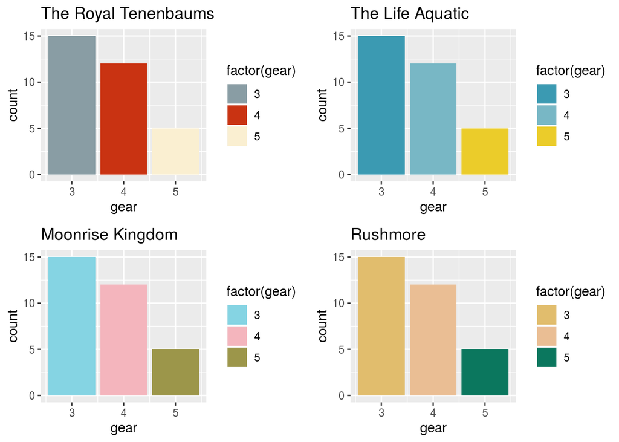

```r
library(wesanderson)
g <- ggplot(mtcars, aes(x = gear, fill = factor(gear))) +
  geom_bar()

g1 <- g + scale_fill_manual(values = wes_palette("Royal1")) +
  ggtitle("The Royal Tenenbaums")
g2 <- g + scale_fill_manual(values = wes_palette("Zissou1")) +
  ggtitle("The Life Aquatic")
g3 <- g + scale_fill_manual(values = wes_palette("Moonrise3")) +
  ggtitle("Moonrise Kingdom")
g4 <- g + scale_fill_manual(values = wes_palette("Rushmore1")) +
  ggtitle("Rushmore")
grid.arrange(g1, g2, g3, g4, ncol = 2, nrow = 2)
```

# The ggthemes package

There is even a package that lets you choose themes that make your whole graph look like graphs from publications like The Economist, The Wall Street Journal, and FiveThirtyEight (Note: Several publications actually use ggplot2 for their graphs. The BBC is another one that I know of.)

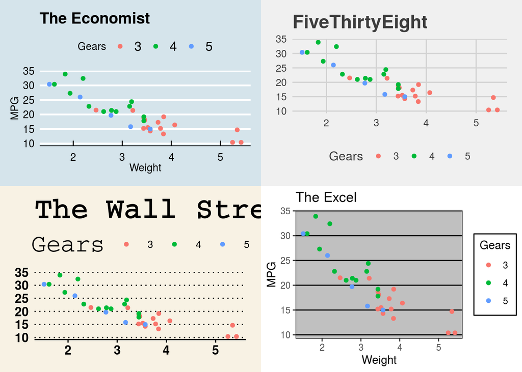

```r
library(ggthemes)
g <- ggplot(mtcars, aes(x = wt, y = mpg, color = factor(gear))) +
  geom_point() +
  labs(color = "Gears", x = "Weight", y = "MPG")

g1 <- g + theme_economist() + ggtitle("The Economist")
g2 <- g + theme_fivethirtyeight() + ggtitle("FiveThirtyEight")
g3 <- g + theme_wsj() + ggtitle("The Wall Street Journal")
g4 <- g + theme_excel() + ggtitle("The Excel")
grid.arrange(g1, g2, g3, g4, ncol = 2, nrow = 2)
```